# Verkilo Business Plan

Helping Authors Manage Their Creativity

Birchfield, Koprowski, Wilson

# Executive Summary

Traditional publishing offers a professional workflow that helps authors turn their creations into publishable products. The publishing field is competitive, resulting in a high author-rejection rate. The self-publishing market comprises one-third of the US publishing market, representing $9.1 billion of the $26 billion in gross US annual book revenue.

The quality of self-published titles is lower than traditional publishing due in part to a lack of professional editing, which, in turn, leads to a growing market of freelance editors. Authors and editors alike are challenged with finding a suitable counterpart who can work within their schedule. Editors are especially frustrated by authors with unrealistic expectations, which leads to lower quality-of-life and burnout in the editing community.

Verkilo seeks to streamline the self-published author workflow through a two-sided platform where authors create their work and are automatically paired with a suitable editor for final collaboration. This will reduce friction in the production process for the author, and by assisting with scheduling we will improve our editor’s quality of life. As a platform, we are like Airbnb and Uber. We generate revenue in two ways: by levying a service charge on author/editor transactions and by charging a monthly subscription to the authors. By establishing a modest foothold in the self-publishing industry by Year 5, we expect to generate $4.5 million in revenue. Our ideal exit strategy is acquisition by Amazon.

No unified, two-sided platform exists in the publishing industry that offers automated author/editor pairing with content creation and automated formatting. Most content creation and editing occur in standalone products like Microsoft Word and Google Docs. Existing pairing platforms like Reedsy rely on manual pairing. Other products in the industry focus on niche aspects such as formatting.

We seek $1.2 million in seed money for 20% in equity so we can beat rivals to market and establish a strong brand presence. Verkilo will use seed funding to finance its first steps, including refined market research and product development. With seed funding, Verkilo can determine what its final products will be and who its target demographic is. We will use seed funding to employ a founding team to complete these tasks. We estimate the return to investors in Year 5 will be $13.2 million. This is an 11x return on the initial $1.2 million investment. This equates to a 62% annual return on investment, each year, over 5 years.

# Value Proposition

## Vision

Verkilo will create a fully integrated, content-creation platform to help self-published authors create professional-grade books by automatically pairing the author with available freelance editors using a machine-learning matchmaking algorithm. Self-published authors need to work with their supporting editor on a schedule that supports the author’s targeted release date and the editor’s hectic schedule. Verkilo is an application that works on any device wherever the author and editor are comfortable. Verkilo’s unique value proposition removes friction from author and editor by automating the production process. This taps into a multibillion-dollar industry in need of optimization.

Verkilo will build a cutting edge, technology-based platform that professionals in the self-publishing market will recognize as the leader in their community. This platform will support and enhance the delivery and time to market of professional-grade, self-published literature. Company primary revenue will be generated by a service charge processed against each editorial transaction conducted by the respective editors. Verkilo will develop and market its own product offering that leverages the agility of cloud technology and dynamically enhanced through data-drive machine learning for speed to market.

## Business Problem

The publishing industry is undergoing tremendous transformation where traditional media is being displaced by self-published authors. This leads to a problem where the author, as creator, must also fill the role of product manager. The author must plan and execute all aspects of production from finding and scheduling editors and cover artists to formatting the final copy and handling distribution and marketing. This steals precious time and energy from the author’s core role as the creative artist.

Likewise, freelance editors are frustrated by the challenges of scheduling and coordinating their work. They work directly with authors who are unfamiliar with the traditional publishing process and find themselves frequently managing authors’ unrealistic schedule expectations and lack of professional discipline —often submitting manuscripts late and changing a draft after it has been submitted. This contention results in work-life balance complaints among freelance editors and tends to produce lower-quality self-published books released to market. Authors and editors would rather focus on their respective specialties and not contend with the hassles of coordinating their work with one another. By creating the solution through Verkilo’s offerings, we help self-published authors work more collaboratively with freelance editors on the editors’ timetable. Our goal here at Verkilo is to improve the quality of self-published books for global consumption in addition to providing a balanced work-life for editors, thus increasing earnings for both author and editor alike.

## Solution

Sequoia Capital, an American venture capital firm, describes American Express, PayPal, eBay, Uber, Facebook, WhatsApp, Netflix, and Amazon all as two-sided platforms. (Sequoia, 2018) These platforms exist as intermediaries to match the supply and demand sides of a market efficiently. Verkilo endeavors to provides a similar two-sided marketplace for editors and authors to collaborate.

Verkilo helps authors and editors create professional, publishable books without all the hassles. We create a collaborative platform where authors and editors can work anywhere, any time by offering a cross-device application (web, Windows, MacOS, iOS, Android, plugins).

## Validation

As discussed in the above Business Problem and Solution sections, market research analysis was completed through web crawling public forums, blogs, and community websites. This includes Reddit’s r/self-publish channel comprising 36,700 members (*Self Published Writers*, n.d.) and the 20BooksTo50K® Facebook group comprising 35,800 members. (*20BooksTo50K®*, n.d.) We conducted an online survey of likely self-published editors via direct Facebook advertisement over a period of two weeks. This market research supported our assumption and suggested baseline requirements to support self-published authors and freelance editors in our target audience. Surveyed editors described their biggest challenge was finding suitable authors who matched their desired genre of editing that had realistic expectations to work within an editor’s schedule. These challenges directly affect the editors’ quality of life, contribute to their daily frustration, and diminish the overall professional relationship with authors.

# Market Analysis

Verkilo initially targets US self-published authors and editors. As discussed below, the US self-publisher market is one-third of the total US published market (itself a quarter of the global market) and is displacing traditional publishing. The overall market should grow modestly for the foreseeable future, with US self-publishers potentially grossing between $9 and $28 billion in annual revenue by 2025. Our market landscape analysis reflects a diverse market of products and services that compete with Verkilo’s vision for attention in the self-publisher market. However, our quantitative assessment suggests none are competing against our complete vision for hassle-free self-publishing.

Verkilo initially plans to target the highly valuable US self-publishing community. The US self-publisher market is one-third of the total US published market (itself a quarter of the global market) and is displacing traditional publishing. The overall market shows considerable growth for the foreseeable future, with estimates grossing between $9 and $28 billion in annual revenue by 2025 for US self-publishers. Our market landscape analysis reflects a diverse market of products and services currently available that compete with Verkilo’s vision for attention in the self-publisher market. However, our quantitative assessment suggests none are competing against our vision of a complete vertical integration of software product offering for hassle-free self-publishing managed through machine learning

## Market Size

[figure not shown]

US Self-Published Books with ISBNs 2013-2018

Technavio, a leading global technology research and advisory company, estimates the global publishing market size will grow by $23 billion to $142 billion between 2020-2024; a 19% increase over the next four years or 6% each year. (“Publishing Market by Platform and Geography - Forecast and Analysis 2020-2024,” 2019) The US market should grow at a similar pace to $33 billion. If US self-publishing grows at the same rate (instead of its historic 30% rate), its market size may reach $11 billion by 2024. At 6% annual growth from Bowker’s 2018 numbers, we estimate a total of 3.8 million self-published books will be released between 2020 and 2025. (“Self-Publishing in the United States, 2013-2018 Print and Ebooks,” 2019)

[figure not shown]

Forecasted Annual Growth of US Self-Published Market 2020-2024

#### What We Need to Enter this Market

We seek $1.2 million in seed money for 20% in equity so we can beat rivals to market and establish a strong brand presence. Verkilo will use seed funding to finance its first steps, including refined market research and product development. With seed funding, Verkilo can determine what its final products will be and who its target demographic is. We will use seed funding to employ a founding team to complete these tasks. We estimate the return to investors in Year 5 will be $13.2 million. This is an 11x return on the initial $1.2 million investment. This equates to a 62% annual return on investment, each year, over 5 years.

## Market Landscape

Our market landscape analysis shows a diverse market of products and services that compete with Verkilo’s vision. Our market assessment aligns with Porter’s Five Forces as applied to software as a service (SaaS). (Niebauer, 2018) The competitive nature of this segment requires we establish brand and product differentiation to stand out. Verkilo seeks to compete by having a complete, compelling vision of the production cycle and automating processes the competition leaves manual.

**New Entrant Threat—High.** The threat of new entrants in any SaaS-related market is high because the ease of establishing infrastructure and product is low.

**Supplier Bargaining Power—Low.** Suppliers such as infrastructure providers have limited bargaining power due to the presence of many infrastructure and platform providers that have commoditized storage, computers, databases, and other services. Supplier costs are a small proportion of any SaaS company’s expenses. (Niebauer, 2018)

**Buyer Bargaining Power—Very High.** The competitive nature of SaaS markets results in companies giving significant information to the customer in the form of pre-sales information, free trials, and low-commitment, monthly rollover contracts. To compete, Verkilo must establish brand loyalty and drive long-term value for the customer.

**Substitute Product Threat / Competitive Rivalry—Very High.** SaaS companies like Verkilo live and die by product differentiation, which creates fierce competitive rivalry as customers have comparably low switching costs. (Niebauer, 2018) We focus on competition in the following section due to our need to differentiate .

## Competition

#### Vision Criteria for a Self-Publishers Platform

1. **Complex Document Project Management.** Enables the self-published author to manage complex and interrelated documents (an entire fiction series or milieu for example)
2. **Intelligent Matchmaking.** Advances machine learning in automating the identification and collaboration of book-publishing professionals
3. **Professional Final Product.** Delivers a final product that is indistinguishable from traditionally published products
4. **Learning Community.** Draws self-published authors together to enhance the writing community and provide fine literature
5. **User Experience.** Overall experience using the product, including how easy or pleasing it is to use.

The table below lists the top products in the self-publishing market that support content creation, revision, publication, or community.

Assessment of Completeness of Vision

| Product | Manage | Match | Output | Com. | UX | Index |
| --- | --- | --- | --- | --- | --- | --- |
| 20Books to 50K | 1 | 1 | 1 | 5 | 3 | 2.2 |
| Freelance Writer’s Den | 1 | 1 | 1 | 3 | 1 | 1.4 |
| Granthika | 4 | 1 | 2 | 2 | 3 | 2.4 |
| Google Docs | 3 | 1 | 2 | 2 | 3 | 2.2 |
| Leanpub | 4 | 1 | 2 | 2 | 3 | 2.4 |
| Microsoft Word | 3 | 1 | 2 | 2 | 3 | 2.2 |
| Reedsy | 1 | 3 | 1 | 3 | 4 | 2.4 |
| Scrivener | 4 | 1 | 2 | 2 | 2 | 2.2 |
| Upwork / Fiver, etc. | 1 | 2 | 1 | 2 | 3 | 1.8 |
| Vellum | 1 | 1 | 4 | 2 | 1 | 1.8 |
| Verkilo | **5** | **5** | **5** | **5** | **3** | **4.6** |

# Customers & Marketing

Marketing is how Verkilo communicates with and reaches its customer segments to deliver its value proposition.

## Customer Segments

Verkilo’s customer base falls into the following major segments:

- **Self-published Author.** The self-published author is either a full- or part-time author. The author is either being fully compensated for managing their own writing or dreams of doing so, and is working toward that goal. The 20BooksTo50K® group is an example of tens of thousands of authors working together to reach that goal. Our target author seeks to write more than one book per year, with an ideal rate being four to six books per year.
- **Freelance Editor.** The freelance editor is a full- or part-time editor. Like the author, the editor has or seeks full-time compensation for helping self-published authors convert their idea into a well-edited product. Some editors are also authors, but by and large, editors tend to congregate in the same online forums as authors or leverage discovery platforms like Reedsy to find their customers.
- **Freelance Artists.** The freelance artist is a full- or part-time artist interested in helping authors create professional-quality cover art. During our initial phase, our focus is on authors and editors to develop product-market fit. We will explore a pivot after we have fit to determine whether to target freelance artists in a subsequent phase.
- **Independent Publishing Companies.** Small-scale independent publishing companies are not part of the large conglomerates or multinational publication companies. These presses make up roughly half of the publishing industry. These companies offer editorial services and attract long-term relationships with published authors. While this segment is distinct from the self-publishing segment, allowing them to work with their authors and editors on a single platform to enrich the experience for their customers and employees. During our initial phase, our focus is on authors and editors to develop products that fit the market. We will explore a pivot after we have to determine whether to target independent publishers in a subsequent phase.

## Customer Engagement

#### Awareness

Verkilo seeks to acquire customers via the following means:

- **Conferences.** Create name and brand recognition by attending and or sponsoring national writing events such as NaNoWriMo and self-publisher-focused conferences. As an example of potential reach, NaNoWriMo had 1.05 million US members in 2019. (*National Novel Writing Month*, 2020)
- **Content Marketing.** Content marketing attracts prospects and transforms prospects into customers by creating and sharing valuable free content. Content marketing helps Verkilo create sustainable brand loyalty, provides valuable information to consumers, and creates a willingness to purchase products from us in the future.
- **Influencers.** Use well-known authors as influencers and public sponsors of the platform. This would include creation of educational video media, sample text documentation, and whitepapers on platform use-case.
- **Social Media Marketing.** Targeted digital marketing on platforms such as Facebook, Twitter, Reddit, and various social media platforms with active users in our customer segments to increase name and brand awareness among self-published authors.
- **User Recommendations.** We incentivize our customers by giving them three subscription-free months for every new customer they recruit on platform who pays a minimum of three months.
- **Seven-Day Free Sign-up.** We conform to the SaaS market norm of providing no-commitment signups by offering a 7-day free signup that will roll over to a monthly subscription.

#### Evaluation & Delivery

Verkilo delivers its value proposition to its customers via:

- **Application Stores.** Verkilo will offer free downloads of its product accessible via the customer’s preferred platform’s app store (e.g. Apple Store, Microsoft Store, Google Play).
- **Verkilo Website.** Verkilo enables free downloads of its product directly from the website. It will also have a browser-based implementation allowing a user to work directly in their preferred browser.

#### Purchase

Verkilo’s customers will purchase subscriptions through the Verkilo website.

#### After-Sales / Customer Relationships

Verkilo is a platform that seeks to establish a long-term indirect relationship with its customer segments. We seek to establish and maintain customer relationships via the following:

- **Initial Active Customer Service.** During the initial startup phase, Verkilo will provide online customer support to identify areas of product or documentation improvement.
- **Community for Shared Self-Service.** We seek to leverage our Community feature to allow users to share knowledge and solve each other’s problems. We will moderate this community in the early stages.
- **Co-Creation.** We seek to use reviews to help users create value by helping one another identify high-quality professionals they can collaborate with.
- **Switching Costs.** We seek to ensure we are providing value by allowing authors to recover their manuscripts via exported Word (.docx) files. By giving them confidence they can switch, we hope to earn their trust. Allowing them to switch ensures we will strive to give them a product worthy of their use.

## Traction Metrics

Financial Traction Metrics

| Metric | Target | Description |
| --- | --- | --- |
| Monthly Recurring Revenue (MRR) | $180K | Predictable monthly income |
| Customers | 2250 | Total customers MoM (new + retained – churn) |
| Customer Lifetime Value | TBD | Net revenue generated by average customer |

Customer Value Traction Metrics

| Metric | Target | Description |
| --- | --- | --- |
| Manuscripts drafted | 750 | Number of books in active draft, which shows customer adoption of composer |
| Editing Services Delivered | 750 | Number of completed edit interactions, which shows successful matchmaking and collaboration between author and editor |
| Manuscripts formatted | 750 | Number of manuscripts finalized and exported for follow-on distribution, which shows author satisfaction in ability to export |

# Business Model

Verkilo provides value via a mobilization platform business model. A platform business model creates value by supporting collaboration between two or more interdependent groups. A mobilization platform helps those groups foster long-term relationships to achieve common goals. This contrasts from an aggregation platform that keeps interactions transactional, such as Uber, and social platforms like Facebook and Reddit where the platform’s focus is social. (Hagel, 2015) Like other platforms, we do not create or manage inventory, although we do support content creation through the platform. Our focus is on the building working relationships between professionals. Our customers create and enhance the value of the creative products they produce.

## Services Offered

Verkilo will provide a comprehensive set of value-added customer services that will cater to our audience segments. These services include:

- **Content Creation.** Authors will experience a comprehensive rich-text interface for creating complex literary work products from short stories to multi-volume series. This created content will be securely stored in the cloud so the author can use any variant of our application (mobile, web, desktop) and enjoy a friendly user experience. Content creation includes storyboarding, outlining, and literary-element management.
- **Editorial Matchmaking.** When a work product is ready for editing, our machine-learning matchmaker will intuitively identify editing professionals with schedule availability that coincides with the product’s release deadline to complete the edit on time without stress.
- **Editing and Version Control.** When a work product is being edited, our platform will provide the review, commenting and revision capabilities expected in industry. This includes tracking multiple revisions and changes between versions so collaborating parties can compare revisions.
- **Production-Ready Formatting.** When a work product is ready for distribution, our application will provide a professional, production-grade export of the product the author can then upload to their preferred distribution system such as Amazon’s Kindle Direct Publishing.
- **Community.** Our platform will encourage users to collaborate to improve their craft and marketability to their target audience.

## How the Service Will Work

Verkilo will facilitate professional self-published literature production, working as follows:

1. **Registration.** Anyone can browse the public portions of the web application. In order to create a work product as author or offer editorial services as editor, the customer will have to register with the application (web, mobile or desktop).
2. **Purchasing Services.** Authors can purchase freelance editors’ editorial services via the application. Authors can solicit bids based on the matchmaking algorithm or respond to editor-directed bids.
3. **Selling services.** Freelance editors can bid on editorial services as requested by the author or as automatically identified by the matchmaker.
4. **Matchmaking.** Authors and editors will be matched via machine-learning algorithms that pair them via the work product’s target audience, genre, and other criteria against the editor’s self-identified preferences. Included in the matchmaking is a rating system that helps identify difficult users or editorial partners each party has enjoyed working with previously.
5. **Formatting.** Authors can export their work product in an automated print/electronic format that is distribution ready. This streamlines the creation process by using established templates that ensure a professional finish.
6. **Community.** Registered platform users in good standing will be encouraged to participate in our community experience using message boards, chats, etc. This will provide added value for the user and platform by improving matchmaking.

## Revenue Streams

Verkilo will build revenues and profits from the following sources:

- **Service Charge.** Verkilo will add a 10% service charge to the editorial bid with a minimum cost threshold based on the size of the work product and type of editorial service performed.
- **User Subscription.** Verkilo charges a nominal monthly user-subscription fee. The subscription drives retention-metrics collection.

# Execution

Verkilo’s execution plan focuses on ensuring we can provide our services to our customer base when- and wherever they choose to write. We are using traditional agile practices for development while we explore product-market best fit. We will maintain our infrastructure as code (IaC), to better manage change and re-constitute our entire ecosystem automatically. We will use private GitHub accounts for managing our code repository. Customer Service will leverage a moderated community approach as discussed in Customer Engagement, supra.

## Technology Solution / Product Development

**Summary.** We provide a multi-operating system application that supports literary work product creation and collaboration based on a JavaScript (JS) codebase. Several backend capabilities will leverage native Amazon Web Service (AWS) cloud functions that provide on-demand capabilities. Machine learning and performance analytics are provided through Amazon SageMaker using PyTorch and GraphQL as Software-as-a-Service (SaaS) within the AWS ecosystem of services. Our service is comprised of eight, frontend and backend, initial components listed below. Each component provides value to the customer by providing a quality user experience and a one-stop interface for developing a creative project from any stage of the production process through to publication.

**Composer (Application Frontend).** The user interface (UI) is a cross-platform application written in Node.JS, leveraging React, Redux, and other related frameworks and libraries. The web application provides a single code base for the other platforms written entirely in JavaScript. We provide cross-platform support for mobile (specifically Android and iOS) devices via React Native. We provide desktop support via Electron. In addition, utilizing an integrated plugin to Microsoft Word will provide support to all the development spaces for authors and editors alike.

These various forms of UI provide a rich-text editor that can be used for composing, editing, and commenting on the book project, leveraging UTF-8 for multi-language support with multiple users able to collaborate in real time. Author/editor interactions are managed on platform, with active-push notifications. Editor-availability calendar is managed in the composer.

**Matchmaker (Application Frontend).** The “Matchmaker” component of the application suite offers a matching interface with profiles, reviews, scheduling and statistics akin to an Amazon marketplace crossed with a Match or Uber like interface. This service leverages predictive analytics (see section below) to help anticipate when an author needs to seek out an editor. It offers the author a set of editors identified by the audience and genre they edit for, the type of editing they provide, and their expected availability. This leverages AWS Lambda serverless Functions-as-a-Service (FaaS), docker containerization, and is written in a Python codebase.

**Data Store (Service Backend).** AWS AppSync will be used to implement GraphQL as a query language that will also our developers to write queries in an object structure over the standard text string. This will greatly reduce the complexity of legacy SQL queries between the front end and backend, which will mean lower direct costs to run API calls on AWS. As AppSync will be used as our API to handle requests from our users and retrieve appropriate data, AWS DynamoDB will be used to support the database services. DynamoDB is a serverless, NoSQL database service on AWS that will auto-scale on its own and will easily integrate with AppSync. To support the “Matchmaker” machine learning model, AWS Elastic Container Service (ECS) will be used as the compute resource for the integrated service offerings of Amazon SageMaker. This will ingest the analysis and supporting data for testing, training, testing, and bias/accuracy analysis to improve the machine learning algorithm. With ECS, we will be using Docker as the container image repository as it is already fully integrated into the ECS services. All customer proprietary data will be encrypted with 256-bit Advanced Encryption Standard (AES) symmetric encryption with private keys being managed through AWS Secrets Manager key-paired through a user-only access/egress account policy. This provides authors with a secure workspace for their projects while also allowing them granular access-control rights to the intellectual property to share with editors and the community at large. This will be provided to the customer through a easy to use UI within the application frontend similar to sharing documents at different Read / Write levels in Google Docs.

**Importer (Service Backend).** This service converts uploaded RTF or DOCX file types into our proprietary format for storage. The process leverages Pandoc and Docker for processing. We virus-scan these uploaded documents as a part of our internal pipeline security. As a milestone event, we plan to implement and support a voice-to-text conversion of uploaded MP3/4 and WAV using AWS Transcribe to provide convenience for self-publishers to record thoughts and storytelling. Inherently, this will also assist visually impaired users with any difficulties they may otherwise encounter by self-publishing through standard means of writing and/or typing their work. Additional support for other services like Amazon Textract (Text-Recognition), Amazon Translate (Language Translation), and Amazon Polly (Text-to-Speech) so an authors and editors can dynamically work across all boundaries of the human senses.

**Exporter (Service Backend).** This service converts the stored work into publication-ready formats (PDF, EPUB, DOCX, RTF) and stores it on the author’s choice of local or cloud-based storage locations (i.e., Dropbox, iCloud, Google Drive, OneDrive, Box, S3). This conversion leverages Pandoc and LaTeX formatters processed using Lambda and Docker-based processing containers.[^2]

**Account Management (Security Backend).** User accounts will be managed by AWS Cognito, a service that provides identity management and access control to our application. Account creation, user/group management, MFA, device management, password policies, and more will be managed through this service to provide layered security and basic account management to our users. User permissions and user rights will be managed in conjunction with a secure enclave database and AWS Cognito groups. This will allow authors and editors to have transparently different permissions and access to the same resources depending on the role they are performing.

Cognito integrates with iOS, Android, Web, and desktop applications as is interconnects via application programming interface (API). Cognito will help the user to set these permissions based on their Verkilo subscription (time until expired, active/expired, etc.).

**Notification (Service Backend).** To automate notifications to our users, as well as to administrators on system-level events and monitoring, we will utilize the AWS Simple Notification Service (SNS) in combination with AWS’ Simple Email Service (SES). SNS/SES are easily integrated into many of the other services AWS offers, including Cognito. This will allow automated email and SMS messages to be sent to users for account-creation directions, self-management of credentials, and subscription related terms and annual renewals. These services will also assist in security event information management, automated incident response and recovery, and other logging/monitoring needs for security-related capabilities implemented into our platform.

**Predictive Analytics (Machine Learning Backend).** To start, the data collected from editors and authors will include their audience, genre, experience, and schedule as a few of the metrics which will serve as inputs for the machine learning models Verkilo intends to deploy. These models will match characteristics of success through similarities and “chance of matching” between the authors and editors, which will serve as the iterative process of building a dynamic recommendation and offerings board for the “Matchmaker” service. The data used to train the models will be derived from preexisting data collected from marketing outreach, known forums and sites through site-scraping web crawling and other data mining processes for an initial application of an algorithm for matching the two-sided relationships with iterative validations and assessments for bias and accuracy after Verkilo’s release through the use of real-time, production data. The initial data types used to train the “Matchmaker” will be a randomized at 80% of the collected data, and the test/validation data sets will comprise approximately 20% of the remainder. Our assumptions through research of best fit algorithms from what we know are the basis for Match.com, Tinder, and E-Harmony is to apply Hierarchical Agglomerative Clustering and K-Means Clustering models written in python to extract high-value relationships based on structured (known metrics) and unstructured data (unknown, derived variables). (Santos, 2020) Structured data types are metrics we have already predetermines through our research and unstructured data is collected from interactions between the author and editors and their use of the platform (i.e., blogs, media, and site-navigations).

We will use Amazon’s SageMaker Studio services to process over fifty (50) industry-leading, optimized, ML-based models utilizing the top three ML platforms (TensorFlow, PyTorch, and Apache MXNet), which are the industry preferred frameworks for text-based input, linear regression, reinforcement, and sentiment training. SageMaker Notebook, Experiment, and Debugger will be directly integrated into AWS’ machine learning services, which will allow quick implementation and delivery of our “Matchmaker” model and allow for a pipeline of additional data analytics and derivations of platform service metrics.

## Product Roadmap / Development Path

Verkilo leverages a platform business model by bringing two different market segments together. Our roadmap focuses on attracting both segments to the platform with the goal of generating revenue principally via the editor segment.

**Phase 1—Composer** involves building the composer capabilities and building out the infrastructure. During this phase, we will be focusing more on the author than the editor to start adding editable data to the platform. Early adopters will receive concierge scheduling by the team while we build out the automated matchmaking & scheduling.

**Phase 2—Matchmaker** involves delivering the automated matchmaking capability. We pilot the capability initially, replacing the concierge scheduling as we gain confidence in the automation’s ability to schedule reliably.

**Phase 3—Scale** expands the offering to a larger audience.

**Phase 4—Exit** involves seeking acquisition by Amazon.

## Key Activities

Verkilo will engage in the following key activities to derive value for our customers:

**Platform.** Verkilo’s business model is dominated by its platform. Activities supporting the platform relate to its management, provisioning, and promotion.

**Author-Editor Coordinating.** Our key differentiator is our ability to match author and editor based on a series of professional and temporal criteria using machine learning and coordinating their schedules automatically. We will manage these proprietary capabilities as trade secrets and develop with a small core team.

**Product Development.** Verkilo is a cloud-based software product company. That is the core of what we do.

## Key Resources

**Platform.** Central to Verkilo’s business model is its platform. This includes the storage, security, privacy, and resiliency of our customers’ data, especially the work products produced by authors. Securely storing this information is as important to us as it is to the author.

**Physical.** Verkilo relies on no physical assets, with the core team working from home.

**Intellectual Property.** Verkilo is primarily a company focused on intellectual property.

- **Trademarks.** Verkilo is currently not trademarked according to the USPTO’s TESS system. We will trademark Verkilo at the earliest opportunity.
- **Patents / Trade Secrets.** We view our matchmaking algorithm as a trade secret rather than something patentable. This position may shift after consulting with a patent attorney.

**Human.** Our core development team is key in developing our algorithm. While we start with part of the team offshore, we onshore the labor in favor of in-house developers as we gain our financial footing.

## Key Partners

Verkilo relies on the following key partners to provide our service to our customers:

**Amazon Web Services.** Verkilo uses a wide range of Amazon Web Services to develop and deliver our services to our customers.

**Adreno Technologies India Pvt. Ltd.** Adreno Technologies (India) Private Limited is one of the leading IT/ITES service providers in India, delivering IT & ITES Solutions to a diverse set of clients in more than 20 countries across the globe. We partner with Adreno to lower product-development costs to accelerate delivery to market.

**CLA LLP.** CLA is a professional services network and the eighth largest accountancy firm in the United States. CLA LLP provides our outsourced accounting support.

# Company

## Management Team & Gaps

Our management team comprises professionals with years of experience in providing cloud and software-development expertise. We are well-suited to bring Verkilo to market, though we seek additional expertise in marketing. Our team will be employed during the start-up period. We welcome expertise from our investor group that can contribute to the success of the company. We include management team skill gaps below.

**Bryan Birchfield (Founder, CMO).** Bryan Birchfield has had an extensive engineering career with a wealth of experience as a systems engineer, solutions architect and network engineer. His experience has spanned business development, sales, product development, and engineering support teams.

**Robert Koprowski (Founder, CTO).** Robert Koprowski is a senior IT solutions architect, systems administrator, and cybersecurity professional supporting various federal government clients. His 12 years of experience is diversified between migration, DevSecOps, and mobile application security within the cloud-computing industry for Amazon Web Services (AWS), Google Cloud Platform (GCP), and Microsoft Azure. His passion for research and development (R&D) in machine learning, artificial intelligence and delivering prototype programs is what drives him. Mr. Koprowski’s expertise aligns well with bringing innovation and speed to market for Verkilo.

**Benjamin Wilson (Founder, CEO).** Ben Wilson is a senior government project manager. He has 17 years’ experience in the technology field supporting efforts in software development, hardware, and organizational change management. He is the founding board president of the Accessible Community, a 503(c) nonprofit startup focused on improving access to small businesses, community organizations, and the surrounding communities for people with disabilities. As an aspiring self-published author, he is sensitive to the needs of the target audience.

**Chief Financial Officer.** Verkilo lacks strong experience in financial planning and risk management. To mitigate this gap in expertise, we plan to outsource the entire accounting operation to CLA, LLP. CLA operates an entire business practice around offering outsourced accounting services, up to and including the CFO position, to small businesses and startups. This allows Verkilo to obtain the expertise required while keeping initial costs low.

## Company Ownership

Grown out of a desire to bring change to the self-published writing community, the management team (Birchfield, Koprowski, & Wilson) founded Verkilo in 2019 to bring an innovative mobilization platform to market. We are currently wholly owned and completely self-funded. To capitalize on our grassroots growth, Verkilo seeks a seed round of investment to establish product-market fit and product development.

## Risk Analysis

Verkilo accepts that, as a startup, it is a bundle of risks. Our risk-management approach looks at major aspects of a startup to determine how to fairly communicate those risks and explain how the company addresses those risks.

We use Leo Polovets’ startup risk management model. (Polovets, 2016a) As an angel investor and venture capitalist, Mr. Polovets suggests key aspects of a startup that should be de-risked. Each risk is scored on a Likert 1-5 scale (Very-High = 5, Very-Low =1). Focusing on systemic startup risk areas avoids a key mistake of undue resource allocation to address minor risks. (Polovets, 2016b)

The following list covers each of Polovets’ suggested risk areas including our self-evaluation and approach to reducing risk. We leverage the approach recommended by Josh Smith, who created a risk-management process and spreadsheet from Mr. Polovets’ model. (Smith, 2017)

Summary of Business Risks

| Category | Risk Level | Mitigation |
| --- | --- | --- |
| Product/Market Fit | Very High | Prototype with early adopters |
| Product Quality | Very High | Prototype with early adopters |
| Sales | Very High | Seek sales/marketing advisor or co-founder |
| Recruiting | High | Seek recruiting advisor or co-founder |
| Short-Term Competition | High | Brand promotion, patent |
| Long-Term Competition | High | Brand promotion |
| Intellectual Property | High | Trademark brand; hire patent attorney |
| Market | Low | Conduct bottom-up analysis of market |
| Team | Low | None, minimal risk |
| Funding | Low | Seeking seed funding |

#### Product/Market Fit Risk—Very High

- Goal: Proving we are building what people want.
- Situation: We think people will use our product based on customer surveys and interviews.
- Mitigation: We will build our prototype in collaboration with early adopters, pivoting as needed to make fit. In this we follow in the footsteps of companies such as Google, Apple, and PayPal, who went from marginal to successful with a change of business model.

#### Product Quality Risk—Very High

- Goal: Proving we can build a high-quality product.
- Situation: We have no prototype, but we are sure we can build one.
- Mitigation: Build the prototype with seed funding using feedback from a small subset of our target audience.

#### Sales Risk—Very High

- Goal: Proving we can sell our product successfully.
- Situation: We have no sales experience.
- Mitigation: We seek an experienced sales/marketing advisor or co-founder to help us mature our capability.

#### Recruiting Risk—High

- Goal: Proving we can grow the team effectively.
- Situation: We have some recruiting experience, and specific team-building experience.
- Mitigation: We seek an experienced recruiting advisor or founder to help us mature our capability.

#### Short-Term Competition Risk—High

- Goal: Proving we are differentiated from others in the market space.
- Situation: There are many competitors that are inefficient at serving our target audience, but there is some differentiation between them.
- Mitigation: With sales in place, establish brand perception and seek a patent on our matchmaking technology, based on recommendation from patent attorney.

#### Long-Term Competition Risk—High

- Goal: Proving defensibility, or that we can position ourselves to compete successfully against copycats.
- Situation: We do not have a real competitive advantage, but we are a first mover in automated professional relationship building between authors and editors.
- Mitigation: With sales in place, establish brand perception.

#### Intellectual Property Risk—High

- Goal: Proving we have protected intellectual property and are not at risk of litigation.
- Situation: We did a cursory patent and trademark evaluation but are not legally competent to do a proper patent search.
- Mitigation: Engage a patent law firm to guide us through the patent portion if we opt for patent. Trademark Verkilo.

#### Market Risk—Low

- Goal: Proving we can execute well and become a successful company.
- Situation: We have conducted top-down market analysis, but not bottom-up analysis backed by experience and data.
- Mitigation: We will continue to improve our model via bottom-up analysis and experimentation.

#### Team Risk—Low

- Goal: Proving we have a team that can achieve our vision.
- Situation: Our core team has technical competence in the key areas.
- Mitigation: None, minimal residual risk.

#### Funding Risk—Low

- Goal: Proving we have enough capital to hit our milestones.
- Situation: With effort, we should be able to break even without capital beyond the seed round.
- Mitigation: Seeking seed funding.

## Exit Strategy

Our exit strategy is acquisition by Amazon, which would enable full vertical integration within the KDP platform. Amazon would then own every aspect of the self-publishing production pipeline—the ability to carry a self-published work from ideation through production to the reader. Our Technology section, *supra*, reflects this strategy by ensuring our application is ready to integrate easily into Amazon’s application infrastructure.

# Financials

Verkilo seeks $1.2 million in seed money for 20% in equity. All investors are offered equity in the firm. Verkilo will invest the $1.2 million to fund product development, marketing, operational expenses, execution of teaming/business agreements, and customer support. Our plan anticipates delivering to market in the first year. As we progress into year 3 and beyond, our revenue from sales will cover our operational and marketing expenses. We forecast that we will be net revenue positive in Year 3, with an EBIT of $77,350.

## Fundraising

To achieve this growth, Verkilo seeks funding via an equity placement to make investments in a variety of areas and fund cash flow requirements for the next 36 months of operation. The Company seeks $1.2 million to finance these activities.

Fundraising Rounds

| Round | Amount | Status | Purpose |
| --- | --- | --- | --- |
| Self | $300K | Planning | Founders investment |
| Seed | $1,200K | Seeking | Product/Market fit, Development, Early Market Growth |
| Series A | TBD |  | Scale, pending early exit opportunity. |

## Use of Proceeds and Funds

The proceeds from this equity financing activity will be used as summarized on the table below.

Summary of Use of Seed Funding

| Expense Area | Amount | Description |
| --- | --- | --- |
| General & Administrative | $57,700 | Subset of the company’s operating expenses |
| Marketing | $131,000 | In-person and virtual marketing to attract platform target audience |
| Operations | $39,100 | Expected platform infrastructure costs |
| Product Development | $471,500 | Salary, licenses and expenses needed to establish the platform |
| Salaries & Related Expenses | $323,800 | Management team salary & benefits |
| Total: | $1,023,100 |  |

The following sections describe in greater detail how we intend to use the funding provided in the Seed round.

#### General & Administrative Expenses

G&A Expenses Estimate

| Category | Year 1 | Description |
| --- | --- | --- |
| Legal Fees | $10,000 | Legal fees include ensuring we have appropriate terms of service, protection from copyright infringement allegations, etc. |
| Outsourced Accounting | $30,000 | CLA LLP to provide outsourced accounting services, to include the CFO position |
| General Liability Insurance | $4,800 | Broad insurance policy providing liability insurance for general business risks |
| Internal Business Apps | $1,800 | Broad insurance policy providing liability insurance for general business risks |
| Computer Equipment | $7,500 | Capital expense for new computer equipment |
| Internet & Phone | $3,600 | Internet and phone service for management team and full-time employees. |
| Total: | $57,700 |  |

#### Marketing Expenses

Marketing Expenses Estimate

| Category | Year 1 | Description |
| --- | --- | --- |
| Content Production | $81,000 | Production of educational and inspirational written and video content |
| Social Media / Digital Marketing | $35,000 | Product advertising on major platforms |
| Trade Show / Conferences | $15,000 | Attend regional & national conferences frequented by our target audience. |
| Total: | $131,000 |  |

#### Operations Expenses

Operations Expenses Estimate

| Category | Year 1 | Description |
| --- | --- | --- |
| Customer Support | $30,600 | Outsourced offshore customer support, including authoring help documentation and user’s manual |
| Hosting Costs | $6,100 | AWS hosting fees |
| Development Tools | $2,400 | Software Development Tools |
| Total: | $39,100 |  |

#### Payroll Expenses

Payroll Expenses Estimate

| Category | Year 1 | Description |
| --- | --- | --- |
| Chief Executive Officer | $108,000 | Full salary & benefits |
| Chief Technology Officer | $108,000 | Full salary & benefits |
| Chief Operations Officer | $108,000 | Full salary & benefits |
| Total: | $324,000 |  |

#### Product Development

During the first year, our initial focus will be on establishing the platform to attract customers. Partnership discovery / matchmaking will start off rudimentary to demonstrate functionality. As we finish the platform, we will shift focus to establishing the machine learning baseline.

Product Development Expenses Estimate

| Category | Year 1 | Description |
| --- | --- | --- |
| In-House Development Team | $210,000 | Salary for in-house development team |
| Outsourced Development Team | $262,000 | Development team producing non-proprietary product features |
| Total: | $472,000 |  |

#### Financial Estimation Assumptions

Our financial plan operates on the following assumptions:

- The historical trend in self-publishing continues for the foreseeable future.
- There would be no unforeseen changes in technology to make our products obsolete. Our underlying software relies on JavaScript, a Top-5 programming language. We are leveraging well-established and well-supported AWS cloud technologies.
- Cash flow is not expected to be a problem, with editing expenses being paid half on request, half on delivery and the service charge levied on request.
- Verkilo’s growth is based on internal financial resources. From year two forward, subject to growth requirements, the company will budget 50% of after-tax profits for growth and 50% for dividends.
- Verkilo’s service fee is percentage-based, using industry standard editing prices.
- Verkilo assumes authors and editors will continue to use the platform after establishing a relationship. We seek to maintain their platform engagement by providing a solid user experience.

## Revenue Estimates

Verkilo will build revenues and profits from the following sources:

- **Service Charge.** Verkilo will add a service charge to the editorial bid that is a fixed percentage of the bid with a minimum cost threshold based on the size of the work product and type of editorial service performed.
- **User Subscription.** Verkilo charges a nominal monthly user subscription fee. The subscription drives metrics collection.

Weighted Editor Pricing

| Edit type | Per Word | Weighting | Total |
| --- | --- | --- | --- |
| Developmental Editing | $0.08 | 30% | $1200.00 |
| Copy Editing | $0.018 | 50% | $450.00 |
| Proofreading | $0.0113 | 100% | $565.00 |
| **Total Cost of Editing** |  |  | **$2,215.00** |

Revenue Streams

| Revenue Streams | Rate | Fee |
| --- | --- | --- |
| Per Book | 10% | $221.50 |
| Per User | $7/mo | $50.00 |

- **Developmental edit.** A thorough edit of a entire manuscript that reviews all the elements from single words and the phrasing of individual sentences, to overall structure and style**
- **Copy Editing.** A general edit addressing grammatical and punctuation errors, incorrect facts, anomalies, inconsistencies and glaring typos.
- **Proofreading.** A detailed edit to find all grammatical, spelling and punctuation errors.
- **Book Size** Edits are made based on total word count. The publishing industry minimum novel length is 50,000, our basis.

#### Service Fee Estimate Assumptions

- Average manuscript length of 50,000, which is the industry-defined minimum size of a fiction novel. Manuscript length is traditionally based on genre ranging between 50-150,000 for fiction and non-fiction ranging up to 200,000 words.
- A manuscript will probably go through multiple edit rounds, with the assumed probability reflected in the estimate.

#### Revenue Estimates

Five-Year Sales Forecast

[output not shown]

Note: Our sales projects are based on a fee structure shown in the section above, multiplied by the books edited via the Verkilo platform.

## Financial Disclaimer

The financial projections that appear in this Business Plan are estimated revenues, expenses, and cash flow, which are based on research and the assumptions discussed throughout this Business Plan. They represent the best of management’s knowledge and belief. The Company’s expected revenues, expenses, and cash flow for the projected periods are subject to the Company’s ability to develop sales and production levels at the price and costs estimated by management. Accordingly, these projections reflect management’s estimates as of date of publication, and its expected course of action if such sales and production levels are attained at the price and costs anticipated.

These projected financial statements are for the purpose of providing updated information to existing and new investors. Do not consider these projected financial statements as a presentation to forecast future results. Accordingly, these projections may not be useful for other purposes.

The assumptions discussed herein are those that management believes are significant to the projections. There may be additional unconsidered assumptions that could materially affect results. Furthermore, even if the sales and production levels as well as the projected price and costs are attained, there will usually be differences between projected and actual results because events and circumstances frequently do not occur as expected, and those differences may be material.

## Valuation

|  | Base | Variation 1 | Variation 2 | Variation 3 | Variation 4 |
| --- | --- | --- | --- | --- | --- |
| Performance | 0% | +20% | -20% | +10% | -10% |
| Probability | 50% | 5% | 10% | 15% | 20% |

# Appendix

## Application UI Design

[figure not shown]

React Stack for Uniform Cross-Platform Experience

Verkilo uses JavaScript, React, ReactNative and ElectronJs for its User Interface code base. This helps us give our user community a consistent user experience and feature set without complicating our code base.

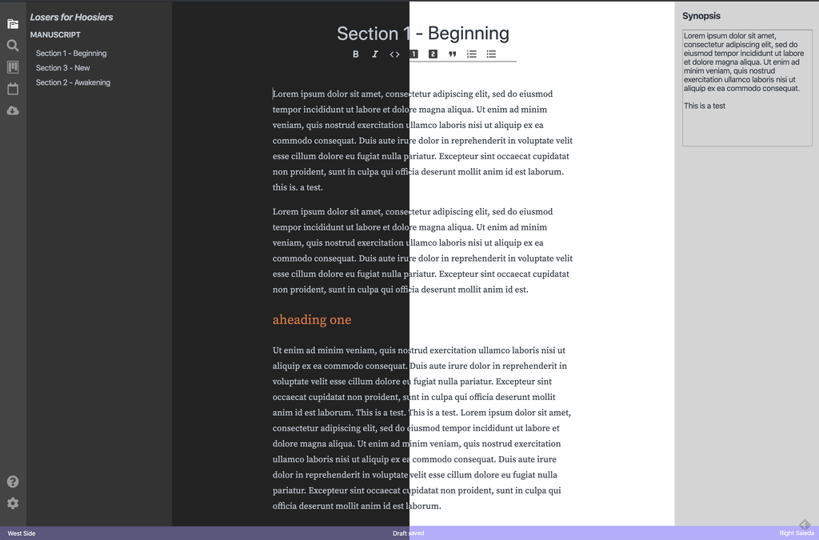

Verkilo Mockup of Editor View (Light / Dark modes)

Verkilo’s user interface mirrors interfaces used by common content editors such as Visual Studio Code, Scrivener and Word. The mockup figure shows an early prototype example of a working editor for a book comprising multiple documents (sections). The interface will allow authors and editors ready access to key features such as the composer, exporter, and matchmaking scheduler. Our early focus is on major features that delight our user community and provide a clean, minimal interface to reduce distractions.

## Application Infrastructure

Verkilo will use many available services and cloud-based techniques to provide scalable availability and automated infrastructure as code. The diagram below describes our high-level infrastructure architecture. This does not preclude adding additional resources, services, or software to manage our Agile development projects.

[figure not shown]

Verkilo Infrastructure Architecture

**High Level Design Principles:**

- AWS Virtual Private Cloud (VPC) network with appropriate Public, Private, and Database Subnets.
- AWS Identify and Access Management (IAM) service for cloud console access for all approved administrators and developers with specific Access Control Lists (ACLs) for each group of users for Least Privilege and Segregation of Duty.
- Initial AWS account compliance will be configured upon creation using AWS SecurityHub to satisfy Center for Internet Security (CIS) version 1.2 standards.
- For payment transactions for processing service fees and editorial transactions, we will apply AWS SecurityHub configurations for monitoring and meeting the Payment Card Industry Security Standards Council’s (PCI-DSS) compliance standard as well.
- Between Verkilo’s connections to systems (EC2) running in our AWS environment, we use OpenVPN servers to manage access into the development and production environments.
- AWS DynamoDB database for User Account controls, credentials, ACLs.
- Stand up frontend webservices for Verkilo primary outreach sites for marketing, forums, blogs, and community tutorials.
- AWS EC2 instances using containerized and serverless Lambda services to process and manage all the Verkilo provided components.
- Verkilo use AWS SageMaker for Machine Learning and its respective Notebooks product to develop tests, bias analysis, and data processing outputs for providing ML-driven results to our customers.
- Other automated security and business tool services will be applied to our product offerings to align with Verkilo’s vision of providing a complete vertical integration of the publishing process. Examples are Textract, Forecast, Transcribe, Polly, etc.

## Customer Support Plan

The Help Desk objective is to deliver support for all Verkilo users and provide high-quality training for the IT Help Desk staff.

Customer Support Channels

| Support Channels | Description |
| --- | --- |
| Self-Help | Hosted, online documentation for the users to access |
| Community Forum | A company-moderated, hosted forum for customers to help one another |
| Social Media | Company-moderated forum on popular social media platforms (e.g. Facebook, Reddit, etc.) |

## Matchmaking Traits

Matchmaking User Traits

| Trait | Description |
| --- | --- |
| Ranking | The net promoter score for the user based on past collaborations |

Matchmaking Manuscript Traits

| Trait | Description |
| --- | --- |
| Genre | Picklist of Target genre for the work |
| Length | Type of manuscript, short, medium, long, derived from the planned length |
| Target Audience | Reading demographic of the manuscript’s target audience (e.g., Child, Youth, Young Adult, Adult) |
| Planned length | Planned length of work, identified by the author |
| Actual length | Actual length of work based on manuscript word count |
| Progress | Completion percentage (Actual length ÷ Planned length) |
| State | Picklist of the overall manuscript state |
| Deadline | When the author wants to submit the manuscript to an editor |

## Bibliography

*20BooksTo50K®*. (n.d.). Retrieved April 9, 2020, from https://www.facebook.com/groups/20Booksto50k/

*Electron*. (n.d.). Retrieved April 13, 2020, from https://www.electronjs.org/

*Global Book Publishing Industry Outlook*. (2019). https://www.ibisworld.com/global/market-research-reports/global-book-publishing-industry/

Hagel, J. (2015). The power of platforms. *Part of the Business Trends Series, Deloitte Insights*.

Magic Quadrant Research Methodology. (2020). In *Gartner*. https://www.gartner.com/en/research/methodologies/magic-quadrants-research

*National Novel Writing Month*. (2020). http://archive.nanowrimo.org/regions

Niebauer, A. (2018). *Porter’s 5 Competitive Forces for SaaS in 5 Minutes*. https://salesupstart.com/2018/07/14/porters5forcesforsaas/

Pofeldt, E. (2019). New Platform Connects Self-Published Authors With Readers. In *Forbes*. https://www.forbes.com/sites/elainepofeldt/2019/03/04/new-platform-connects-self-published-authors-with-readers/

Polovets, L. (2016a). *How to De-Risk a Startup*. https://codingvc.com/how-to-de-risk-a-startup/

Polovets, L. (2016b). *Startups are Risk Bundles*. https://codingvc.com/startups-are-risk-bundles/

Publishing Market by Platform and Geography - Forecast and Analysis 2020-2024. (2019). In *Technavio*. https://www.technavio.com/report/publishing-market-size-industry-analysis

*React – A JavaScript library for building user interfaces*. (n.d.). Retrieved April 13, 2020, from https://reactjs.org/

*React Native*. (n.d.). Retrieved April 13, 2020, from https://reactnative.dev/

Santos, M. (2020). Dating Algorithms using Machine Learning and AI. In *Medium*. https://towardsdatascience.com/dating-algorithms-using-machine-learning-and-ai-814b68ecd75e

*Self Published Writers*. (n.d.). Retrieved April 9, 2020, from https://www.reddit.com/r/selfpublish/

*Self-Publishing Grew 40 Percent in 2018, New Report Reveals*. (2019). http://www.bowker.com/news/2019/Self-Publishing-Grew-40-Percent-in-2018-New-Report--Reveals.html

Self-Publishing in the United States, 2013-2018 Print and Ebooks. (2019). *Bowker*. https://media2.proquest.com/documents/bowker-selfpublishing-report2019.pdf

Sequoia. (2018). Two-Sided Marketplaces and Engagement. In *Medium*. https://medium.com/sequoia-capital/two-sided-marketplaces-and-engagement-ded7d5dcfe71

Smith, J. (2017). *Lower your startup risk with this template Code Corps*. https://blog.codecorps.org/lower-your-startup-risk-with-this-template/

*State Of React Native Development At The Beginning Of 2020*. (n.d.). Retrieved April 13, 2020, from https://www.ideamotive.co/blog/state-of-react-native-development-at-the-beginning-of-2020

*Visual Studio Code 2.6M Users, 12 months of momentum and more to come.* (2017). https://code.visualstudio.com/blogs/2017/11/16/connect

Watson, A. (2019). Book sales statistics U.S. In *Statista*. https://www.statista.com/statistics/271931/revenue-of-the-us-book-publishing-industry/

[^1]: Bowker warned that many books in 2018 were distributed via Amazon’s Kindle without ISBNs, which means the total number of self-published books exceeds the Bowker reported number. (“Self-Publishing in the United States, 2013-2018 Print and Ebooks,” 2019) We limited our analysis to verifiable numbers provided by Bowker.
[^2]: Note: We used a prototype of Verkilo’s Exporter to create the document you are now reading.